# Predicting exercise quality using Random Forests

As an occasional Gym goer my perception of the health and fitness business is that its focus is very unbalanced towards nutrition, what should you eat, what supplements will make you bigger and leaner, and general trends like Zumba and CrossFit, and much less on the results of the exercises and/or its form and posture.

When you think about long term health and fitness one aspect that is overlooked is the downtime due to injuries and a quick Google search will reveal thousands of articles about injuries that are results of bad posture and exercise form. Thanks to the new technologies like Jawbone Up, Nike FuelBand, and Fitbit and the datasets provided by the researchers in PUC-RIO we are able to quantify what makes a bad exercise form.

Using the Weight Lifting Exercises Dataset from http://groupware.les.inf.puc-rio.br/har we intend to create a model which is able to predict the quality of the movements based on measurements from several sensors located on the arms, belt and dumbbells.

### The Data

#### Load libraries

```r
library(dplyr)
library(tidyr)
library(lubridate)
library(caret)
library(randomForest)
```

#### Download data

```r
data <- read.csv('http://d396qusza40orc.cloudfront.net/predmachlearn/pml-training.csv')
```

Let’s look at the data to verify its quality

```r
str(data[1:20])
```

```
## 'data.frame':    19622 obs. of  20 variables:
##  $ X                   : int  1 2 3 4 5 6 7 8 9 10 ...
##  $ user_name           : Factor w/ 6 levels "adelmo","carlitos",..: 2 2 2 2 2 2 2 2 2 2 ...
##  $ raw_timestamp_part_1: int  1323084231 1323084231 1323084231 1323084232 1323084232 1323084232 1323084232 1323084232 1323084232 1323084232 ...
##  $ raw_timestamp_part_2: int  788290 808298 820366 120339 196328 304277 368296 440390 484323 484434 ...
##  $ cvtd_timestamp      : Factor w/ 20 levels "02/12/2011 13:32",..: 9 9 9 9 9 9 9 9 9 9 ...
##  $ new_window          : Factor w/ 2 levels "no","yes": 1 1 1 1 1 1 1 1 1 1 ...
##  $ num_window          : int  11 11 11 12 12 12 12 12 12 12 ...
##  $ roll_belt           : num  1.41 1.41 1.42 1.48 1.48 1.45 1.42 1.42 1.43 1.45 ...
##  $ pitch_belt          : num  8.07 8.07 8.07 8.05 8.07 8.06 8.09 8.13 8.16 8.17 ...
##  $ yaw_belt            : num  -94.4 -94.4 -94.4 -94.4 -94.4 -94.4 -94.4 -94.4 -94.4 -94.4 ...
##  $ total_accel_belt    : int  3 3 3 3 3 3 3 3 3 3 ...
##  $ kurtosis_roll_belt  : Factor w/ 397 levels "","-0.016850",..: 1 1 1 1 1 1 1 1 1 1 ...
##  $ kurtosis_picth_belt : Factor w/ 317 levels "","-0.021887",..: 1 1 1 1 1 1 1 1 1 1 ...
##  $ kurtosis_yaw_belt   : Factor w/ 2 levels "","#DIV/0!": 1 1 1 1 1 1 1 1 1 1 ...
##  $ skewness_roll_belt  : Factor w/ 395 levels "","-0.003095",..: 1 1 1 1 1 1 1 1 1 1 ...
##  $ skewness_roll_belt.1: Factor w/ 338 levels "","-0.005928",..: 1 1 1 1 1 1 1 1 1 1 ...
##  $ skewness_yaw_belt   : Factor w/ 2 levels "","#DIV/0!": 1 1 1 1 1 1 1 1 1 1 ...
##  $ max_roll_belt       : num  NA NA NA NA NA NA NA NA NA NA ...
##  $ max_picth_belt      : int  NA NA NA NA NA NA NA NA NA NA ...
##  $ max_yaw_belt        : Factor w/ 68 levels "","-0.1","-0.2",..: 1 1 1 1 1 1 1 1 1 1 ...
```

## Cleaning the dataset

Before we start the modeling process we have to clean this dataset because there are some missing values, some columns contain the ‘#DIV/0’ which is an error value and there are lots of NAs in this data.

We will import again the data, but this time we will force the missing values and the ‘#DIV/0’ into NAs

> One important thing to consider: This data came from the Machine Learning Course in Coursera and was labeled training and testing, but there is no way to actually test the results in this dataset without submitting them to Coursera.

> We will re-label the testing data as ‘Validation’ and using the training dataset (which has over 19000 observations), we will create both training and testing datasets for this exercise.

```r
data <- read.csv('http://d396qusza40orc.cloudfront.net/predmachlearn/pml-training.csv',stringsAsFactors = F, na.strings=c('#DIV/0', '', 'NA'))

validation <- read.csv('https://d396qusza40orc.cloudfront.net/predmachlearn/pml-testing.csv', stringsAsFactors = F, na.strings=c('#DIV/0', '', 'NA'))
```

#### Dealing with NA’s

Now we will have a look at the columns that have NAs because there are several columns that are full of NA values, those must removed from the training set.

```r
na_count <-sapply(data, function(y) sum(length(which(is.na(y)))))
head(na_count[na_count>0])
```

```
##   kurtosis_roll_belt  kurtosis_picth_belt    kurtosis_yaw_belt
##                19216                19216                19216
##   skewness_roll_belt skewness_roll_belt.1    skewness_yaw_belt
##                19216                19216                19216
```

The pattern here is that for some measures more than 95% of the observations are missing. We will discard those variables. The remaining variables will be used in the model.

```r
na_pos <- na_count>19000
cols <- data.frame(COL=seq(1:length(data)), TF=na_pos)
data2 <- data[,cols$COL[cols$TF=='FALSE']]

sapply(data2, function(y) sum(length(which(is.na(y)))))
```

```
##                    X            user_name raw_timestamp_part_1
##                    0                    0                    0
## raw_timestamp_part_2       cvtd_timestamp           new_window
##                    0                    0                    0
##           num_window            roll_belt           pitch_belt
##                    0                    0                    0
##             yaw_belt     total_accel_belt         gyros_belt_x
##                    0                    0                    0
##         gyros_belt_y         gyros_belt_z         accel_belt_x
##                    0                    0                    0
##         accel_belt_y         accel_belt_z        magnet_belt_x
##                    0                    0                    0
##        magnet_belt_y        magnet_belt_z             roll_arm
##                    0                    0                    0
##            pitch_arm              yaw_arm      total_accel_arm
##                    0                    0                    0
##          gyros_arm_x          gyros_arm_y          gyros_arm_z
##                    0                    0                    0
##          accel_arm_x          accel_arm_y          accel_arm_z
##                    0                    0                    0
##         magnet_arm_x         magnet_arm_y         magnet_arm_z
##                    0                    0                    0
##        roll_dumbbell       pitch_dumbbell         yaw_dumbbell
##                    0                    0                    0
## total_accel_dumbbell     gyros_dumbbell_x     gyros_dumbbell_y
##                    0                    0                    0
##     gyros_dumbbell_z     accel_dumbbell_x     accel_dumbbell_y
##                    0                    0                    0
##     accel_dumbbell_z    magnet_dumbbell_x    magnet_dumbbell_y
##                    0                    0                    0
##    magnet_dumbbell_z         roll_forearm        pitch_forearm
##                    0                    0                    0
##          yaw_forearm  total_accel_forearm      gyros_forearm_x
##                    0                    0                    0
##      gyros_forearm_y      gyros_forearm_z      accel_forearm_x
##                    0                    0                    0
##      accel_forearm_y      accel_forearm_z     magnet_forearm_x
##                    0                    0                    0
##     magnet_forearm_y     magnet_forearm_z               classe
##                    0                    0                    0
```

#### Removing variables that will not be used

```r
data2 <- data2 %>% select(-X,-user_name, -raw_timestamp_part_1, -raw_timestamp_part_2, -cvtd_timestamp, -new_window, -num_window)
```

### Split dataset into Training and Testing

Now that we have a clean dataset, we can slit it into Training and Testing and to do that, we will use the standard 0.7% training and 0.3% testing

```r
inTrain <- createDataPartition(data2$classe, p=0.7, list=F)
train <- data2[inTrain,]
test <- data2[-inTrain,]
```

## Modeling

```r
set.seed(12345)
modFit <- randomForest(factor(classe) ~ . , data=train,ntree=1000,importance=TRUE)
```

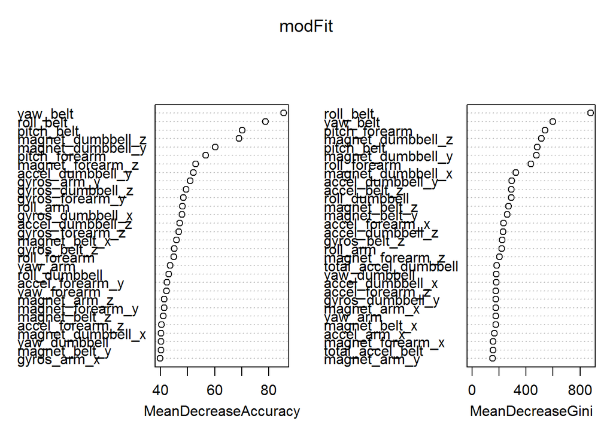

```r
varImpPlot(modFit)
```

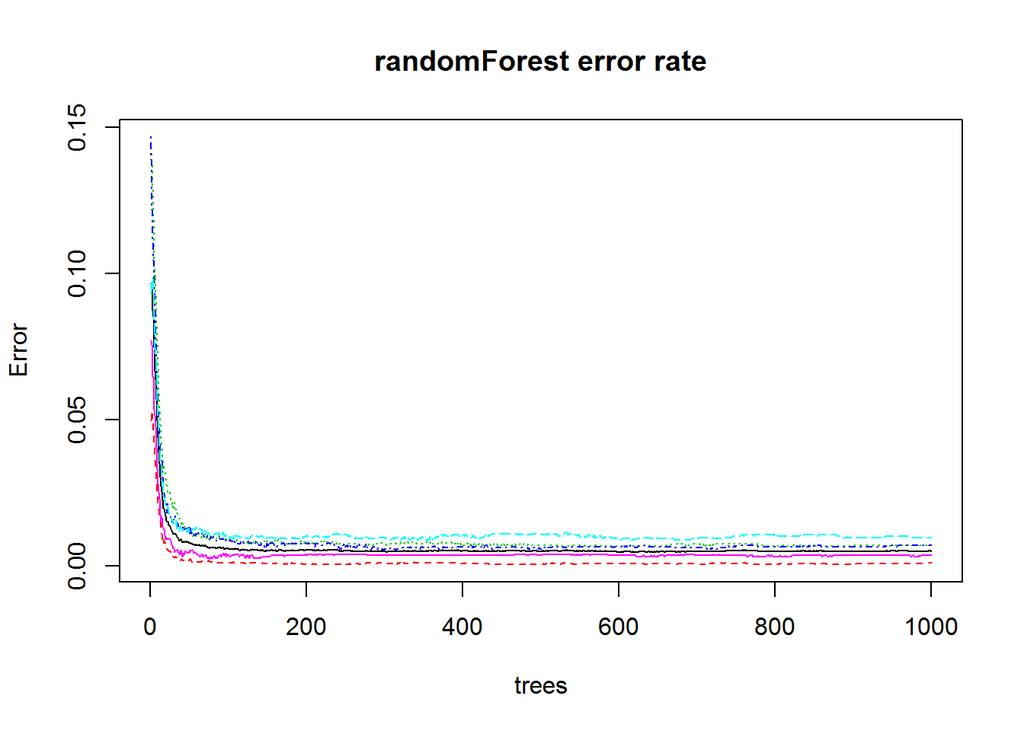

```r
plot(modFit,main='randomForest error rate')
```

### Cross Validation

Observing the results in the Training set

```r
pred <- predict(modFit,newdata=train)
CM <- confusionMatrix(train$classe, pred)
CM$table
```

```
##           Reference
## Prediction    A    B    C    D    E
##          A 3906    0    0    0    0
##          B    0 2658    0    0    0
##          C    0    0 2396    0    0
##          D    0    0    0 2252    0
##          E    0    0    0    0 2525
```

Observing the results in the Testing set

```r
pred2 <- predict(modFit,newdata=test)
CM2 <- confusionMatrix(test$classe, pred2)
CM2
```

```
## Confusion Matrix and Statistics
##
##           Reference
## Prediction    A    B    C    D    E
##          A 1672    0    1    0    1
##          B    5 1134    0    0    0
##          C    0    8 1017    1    0
##          D    0    0    6  957    1
##          E    0    0    4    2 1076
##
## Overall Statistics
##
##                Accuracy : 0.9951
##                  95% CI : (0.9929, 0.9967)
##     No Information Rate : 0.285
##     P-Value [Acc > NIR] : < 2.2e-16
##
##                   Kappa : 0.9938
##  Mcnemar's Test P-Value : NA
##
## Statistics by Class:
##
##                      Class: A Class: B Class: C Class: D Class: E
## Sensitivity            0.9970   0.9930   0.9893   0.9969   0.9981
## Specificity            0.9995   0.9989   0.9981   0.9986   0.9988
## Pos Pred Value         0.9988   0.9956   0.9912   0.9927   0.9945
## Neg Pred Value         0.9988   0.9983   0.9977   0.9994   0.9996
## Prevalence             0.2850   0.1941   0.1747   0.1631   0.1832
## Detection Rate         0.2841   0.1927   0.1728   0.1626   0.1828
## Detection Prevalence   0.2845   0.1935   0.1743   0.1638   0.1839
## Balanced Accuracy      0.9983   0.9960   0.9937   0.9977   0.9984
```

The model have a very high accuracy, perfectly predicting values in the Training set, but still having a very high accuracy in the Testing set, although it misses some classifications as expected.